# Número Básico de Reproducción en México

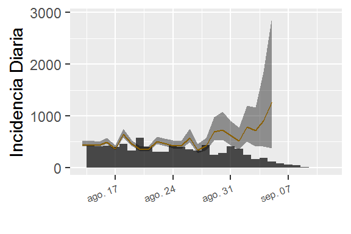

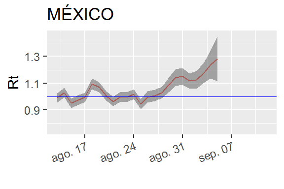

```
##    Rt    sd      fecha
##  1.29 0.173 2020-09-05
```

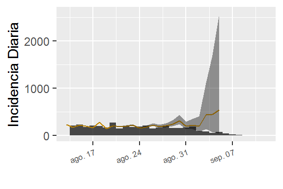

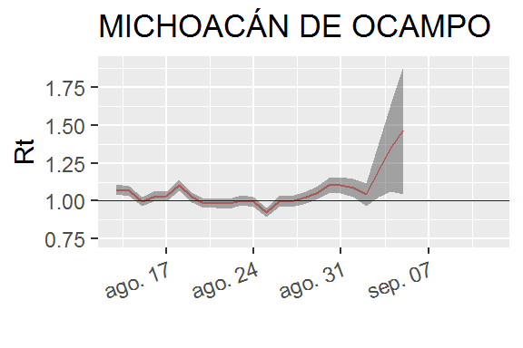

```
##    Rt    sd      fecha
##  1.47 0.426 2020-09-05
```

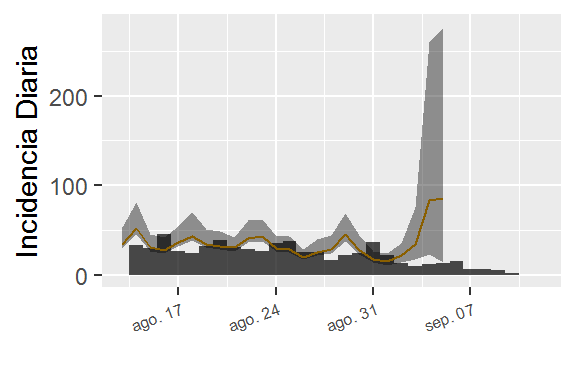

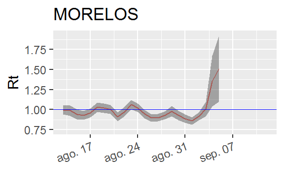

```
##    Rt   sd      fecha
##  1.51 0.41 2020-09-05
```

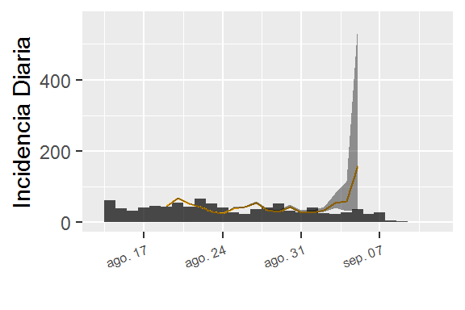

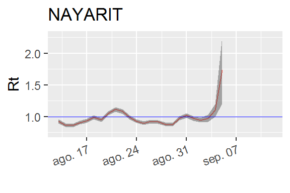

```
##    Rt    sd      fecha
##  1.74 0.532 2020-09-05
```

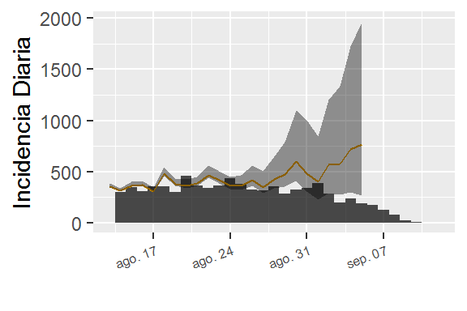

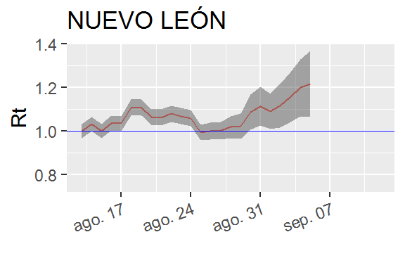

```
##    Rt    sd      fecha
##  1.22 0.152 2020-09-05
```

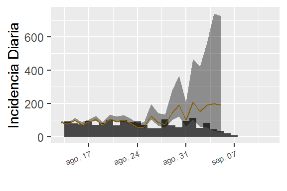

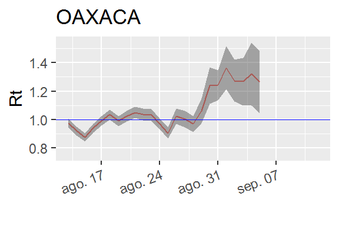

```
##    Rt   sd      fecha
##  1.26 0.22 2020-09-05
```

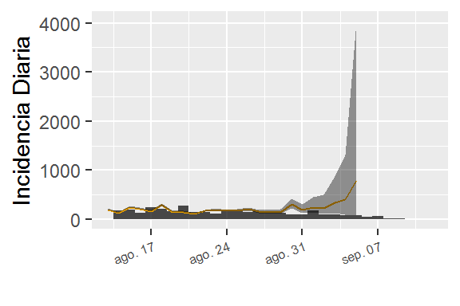

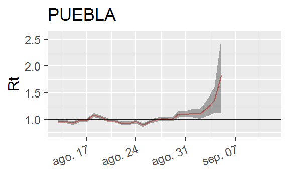

```
##    Rt    sd      fecha
##  1.83 0.724 2020-09-05
```

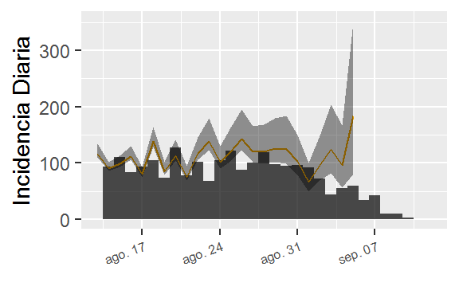

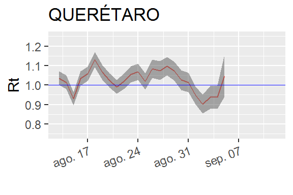

```
##    Rt    sd      fecha
##  1.05 0.109 2020-09-05
```

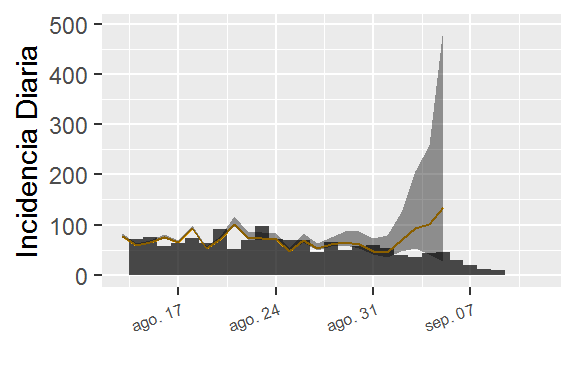

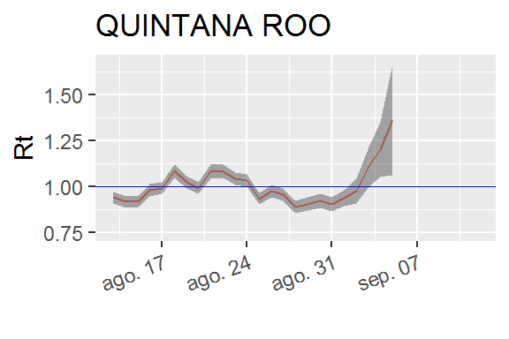

```
##    Rt    sd      fecha
##  1.36 0.304 2020-09-05
```

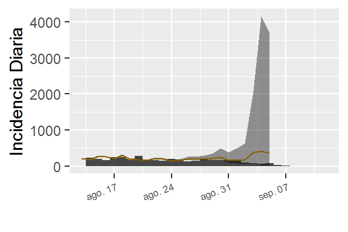

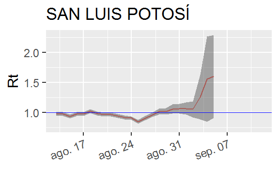

```
##   Rt    sd      fecha
##  1.6 0.686 2020-09-05
```

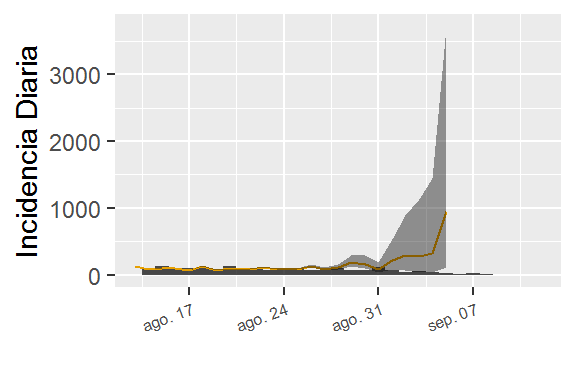

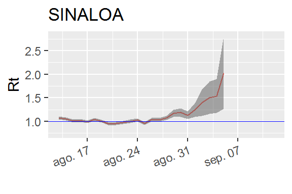

```
##    Rt    sd      fecha
##  2.03 0.769 2020-09-05
```

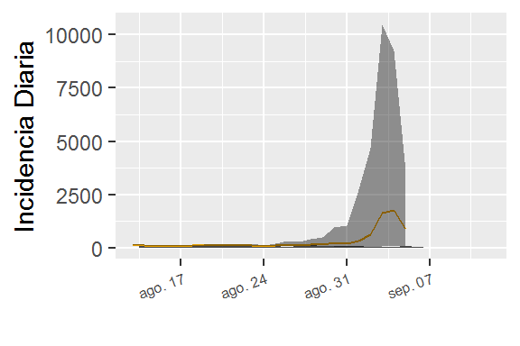

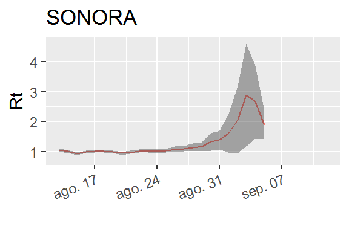

```
##    Rt   sd      fecha
##  1.88 0.46 2020-09-05
```

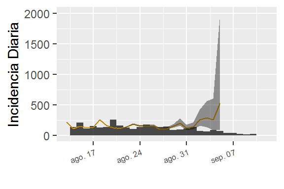

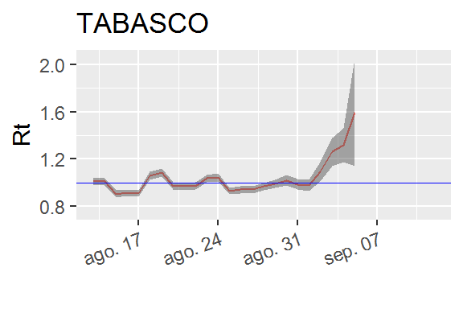

```
##   Rt    sd      fecha
##  1.6 0.455 2020-09-05
```

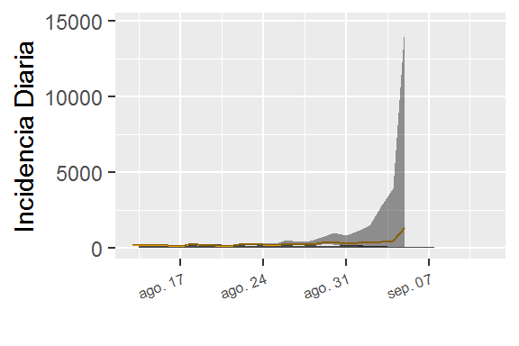

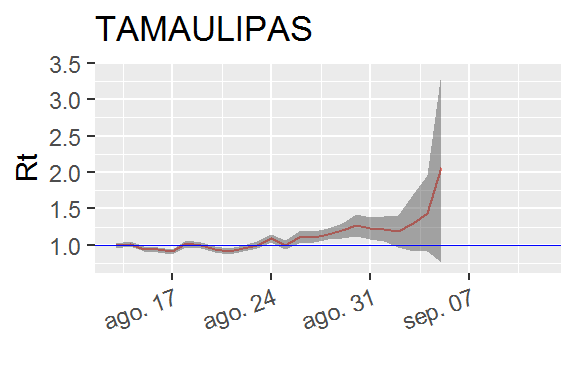

```
##    Rt  sd      fecha
##  2.06 1.3 2020-09-05
```

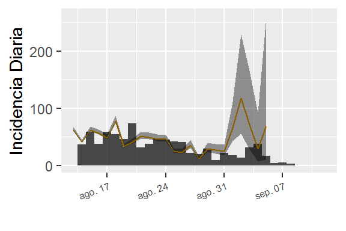

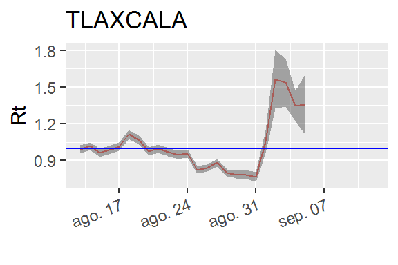

```
##    Rt    sd      fecha
##  1.36 0.241 2020-09-05
```

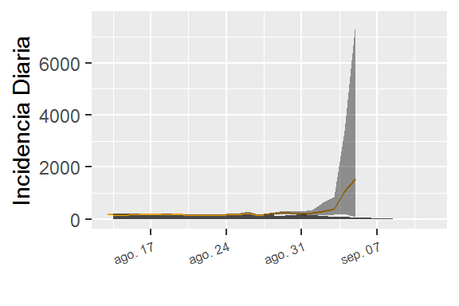

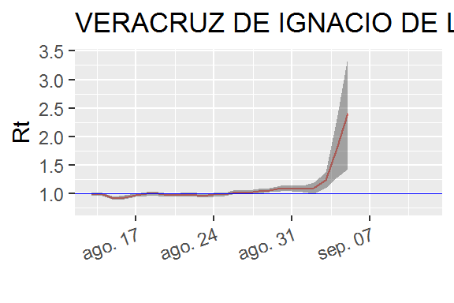

```
##    Rt    sd      fecha
##  2.41 0.985 2020-09-05
```

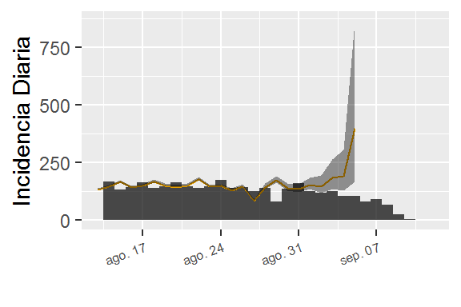

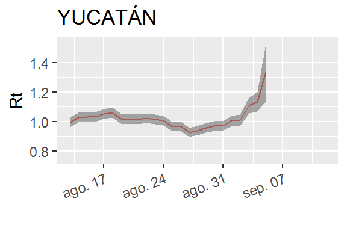

```
##    Rt    sd      fecha
##  1.33 0.195 2020-09-05
```

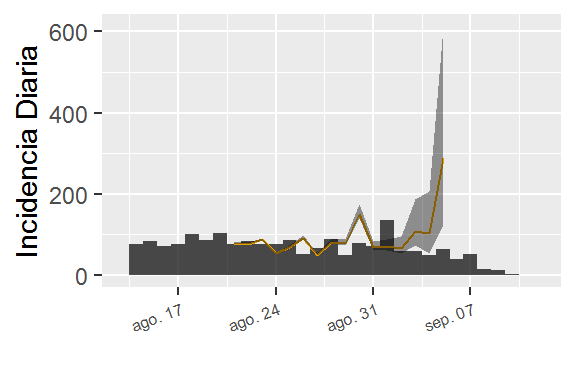

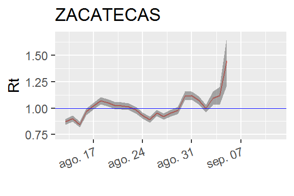

```
##    Rt    sd      fecha
##  1.45 0.229 2020-09-05
```

## Introducción

A medida que aumenta la interacción entre las personas, se materializa la amenaza inminente de los brotes de COVID-19, y existe una inclinación a aplicar bloqueos. En este contexto, es esencial tener indicadores fáciles de usar que podamos emplear como referencia. El número básico de reproducción de positivos confirmados, $R_t$, puede cumplir ese rol. Este documento presenta el resultado de aplicar un enfoque basado en datos para el pronóstico del $R_t$ inmediato basado en el comportamiento estadístico de observaciones anteriores. A medida que llega más información, el método naturalmente se vuelve más preciso sobre el recuento final de positivos confirmados. La fortaleza de nuestro método es que se basa en el inicio de síntomas autoinformados, en contraste con otros métodos que utilizan el recuento diario para inferir $R_t$. Creemos que el empleo de $R_t$ puede ser la base para determinar indicadores útiles de seguimiento de epidemias.

## Aproximación

El presente trabajo está basado en la idea de explotar el patrón de regularidad con la que se actualizan las cifras de confirmados positivos a COVID-19 (Salas 2020). En nuestra aproximación, construimos funciones de probabilidad que permiten estimar cual será el número de confirmados positivos para un cierto día habiéndose dado actualizaciones para esa misma fecha. Ya con el número estimado de confirmados positivos, se construyen posibles series de evolución del número de confirmados positivos.

Para la determinación del número básico de reproducción para una de esas series de tiempo, nos basamos en la librería para **R** (el lenguaje) *EpiEstim*, la cual se construye alrededor del trabajo de Cori *et al.* (2013). Cori *et al.* asumieron que la tasa a la que una persona infectada contagia a otras sigue un proceso de Poisson. Enseguida utilizan un proceso de inferencia bayesiano en donde asumen un *prior* en la forma de una distribución Gamma, lo cual resulta en un *posterior* que también sigue una distribución Gamma. Siguiendo la recomendación de Cori *et al.* solo calculamos $R_t$ cuando el número de casos es mayor a 12 infectados. Además, siguiendo un estudio de periodicidad propio, calculamos $\tau$ como una semana. Finalmente, usando la investigación de Aghaali *et al.*(2020) asignamos una media de 4.55 y una desviación estándar de 3.30 al *prior* Gamma. Notando que la caracterización del intervalo serial varía ampliamente y posiblemente requiera valores que reflejen la dinámica del país (Griffin et al. 2020). La estimación de $R_t$ que proporcionamos tiene la media y desviación estándar en ese momento.

Nuestros resultados toman en cuenta la transmisión pre-sintomática, *i.e.*, el periodo de incubación, o el tiempo que toma a un infectado comenzar a mostrar síntomas, es mayor al periodo latente, o el tiempo a partir del cual un infectado puede contagiar a otros. Siguiendo Bar-On *et al.*(2020) asumimos que el periodo latente dura tres días y el periodo de incubación cinco días.

## Términos y Condiciones

Términos y condiciones: Este reporte ha sido elaborado por “el autor” y se proporciona al público estrictamente para la salud pública, la educación, y la investigación académica. El reporte se basa en datos hechos públicos por la Secretaría de Salud de México y código que está disponible en el blog de información: https://tinyurl.com/nowcastRt. “El autor” declara que no ofrece garantías con respecto al reporte, incluida la precisión, la idoneidad para el uso, y la fiabilidad. Se prohíbe estrictamente confiar en el reporte para obtener orientación médica o usar el reporte para fines comerciales. También se prohíbe estrictamente el uso de este reporte, su información y la documentación puesta a disposición con fines promocionales o comerciales. Consulte la información oficial de la Secretaría de Salud de México en donde expertos ayudan a mejorar la comprensión del virus SARS-CoV-2, informar al público, formular políticas para guiar una respuesta, mejorar la atención y salvar vidas.

## Mayor Información:

Joaquín Salas. Instituto Politécnico Nacional. Cerro Blanco 141, Colinas del Cimatario, Querétaro, CP 76090, México. salas@ieee.org, jsalasr@ipn.mx

# References

Aghaali, Mohammad, Goodarz Kolifarhood, Roya Nikbakht, Hossein Mozafar Saadati, and Seyed Saeed Hashemi Nazari. 2020. “Estimation of the Serial Interval and Basic Reproduction Number of COVID-19 in Qom, Iran, and Three Other Countries: A Data-Driven Analysis in the Early Phase of the Outbreak.” *Transboundary and Emerging Diseases*. Wiley Online Library.

Bar-On, Yinon M, Avi Flamholz, Rob Phillips, and Ron Milo. 2020. “Science Forum: SARS-CoV-2 (COVID-19) by the numbers.” *Elife* 9. eLife Sciences Publications Limited: e57309.

Cori, Anne, Neil Ferguson, Christophe Fraser, and Simon Cauchemez. 2013. “A New Framework and Software to Estimate Time-Varying Reproduction Numbers during Epidemics.” *American Journal of Epidemiology* 178 (9). Oxford University Press: 1505–12.

Griffin, John, Aine Collins, Kevin Hunt, David McEvoy, Miriam Casey, Andrew Byrne, Conor McAloon, Ann Barber, Elizabeth Ann Lane, and Simon More. 2020. “A Rapid Review of Available Evidence on the Serial Interval and Generation Time of COVID-19.” *medRxiv*. Cold Spring Harbor Laboratory Press.

Salas, Joaquín. 2020. “Improving the Estimation of the COVID-19 Basic Reproduction Number using Nowcasting.” *arXiv:2007.09800*.